# Between Sample (Beta) Diversity of Microbes along a Salinity Gradient

```r
raw_rooted_physeq <-
  midroot_physeq %>%
  # remove lowly seq sample that was outlier in alpha diversity analysis
  subset_samples(names != "SRR11364374") %>%
  # any asvs unique to this sample will also be removed
  prune_taxa(taxa_sums(.) > 0, .)

# Inspect
raw_rooted_physeq
```

```
## phyloseq-class experiment-level object
## otu_table()   OTU Table:         [ 6470 taxa and 59 samples ]
## sample_data() Sample Data:       [ 59 samples by 44 sample variables ]
## tax_table()   Taxonomy Table:    [ 6470 taxa by 9 taxonomic ranks ]
## phy_tree()    Phylogenetic Tree: [ 6470 tips and 6469 internal nodes ]
```

```r
# what is the minimum number of sequences
raw_rooted_physeq %>%
  sample_sums() %>%
  min()
```

```
## [1] 17469
```

## Normalize read counts

```r
### scale_reads function
####################################################################################
# Function to scale reads: http://deneflab.github.io/MicrobeMiseq/
# Scales reads by
# 1) taking proportions
# 2) multiplying by a given library size of n
# 3) rounding
# Default for n is the minimum sample size in your library
# Default for round is floor

matround <- function(x){trunc(x+0.5)}

scale_reads <- function(physeq, n = min(sample_sums(physeq)), round = "round") {

  # transform counts to n
  physeq.scale <- transform_sample_counts(physeq, function(x) {(n * x/sum(x))})

  # Pick the rounding functions
  if (round == "floor"){
    otu_table(physeq.scale) <- floor(otu_table(physeq.scale))
  } else if (round == "round"){
    otu_table(physeq.scale) <- round(otu_table(physeq.scale))
  } else if (round == "matround"){
    otu_table(physeq.scale) <- matround(otu_table(physeq.scale))
  }

  # Prune taxa and return new phyloseq object
  physeq.scale <- prune_taxa(taxa_sums(physeq.scale) > 0, physeq.scale)
  return(physeq.scale)
}
```

## Scale the reads and check the distribution of the seq depth

This is where one might decide use rarefaction to normalize data.

```r
min(sample_sums(raw_rooted_physeq))
```

```
## [1] 17469
```

```r
# Scale reads by the above function
scaled_rooted_physeq <-
  raw_rooted_physeq %>%
  scale_reads(round = "matround")

# Calculate the read depth
scaled_TotalSeqs_df <-
  scaled_rooted_physeq %>%
  sample_sums() %>%
  data.frame()
colnames(scaled_TotalSeqs_df)[1] <-"TotalSeqs"

# Inspect
head(scaled_TotalSeqs_df)
```

```
##             TotalSeqs
## SRR11364336     17478
## SRR11364337     17490
## SRR11364338     17457
## SRR11364339     17453
## SRR11364340     17491
## SRR11364341     17490
```

```r
# Check the range of the data
min_seqs <- min(scaled_TotalSeqs_df$TotalSeqs); min_seqs
```

```
## [1] 17422
```

```r
max_seqs <- max(scaled_TotalSeqs_df$TotalSeqs); max_seqs
```

```
## [1] 17509
```

```r
# range
max_seqs - min_seqs
```

```
## [1] 87
```

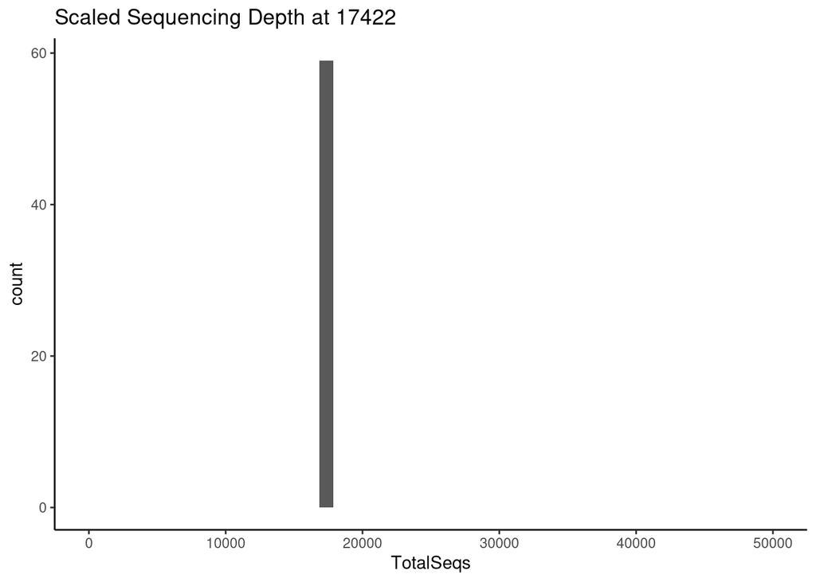

```r
# Plot Histogram
scaled_TotalSeqs_df %>%
  ggplot(aes(x = TotalSeqs)) +
  geom_histogram(bins = 50) +
  scale_x_continuous(limits = c(0, 50000)) +
  labs(title = "Scaled Sequencing Depth at 17422") +
  theme_classic()
```

# Cacluate & Visualize community dissimilarity

Exploratory analyses from Paliy & Shankar (2016) paper, which is using unconstrained ordination methods like PCoA.

## PCoA

### Sorensen

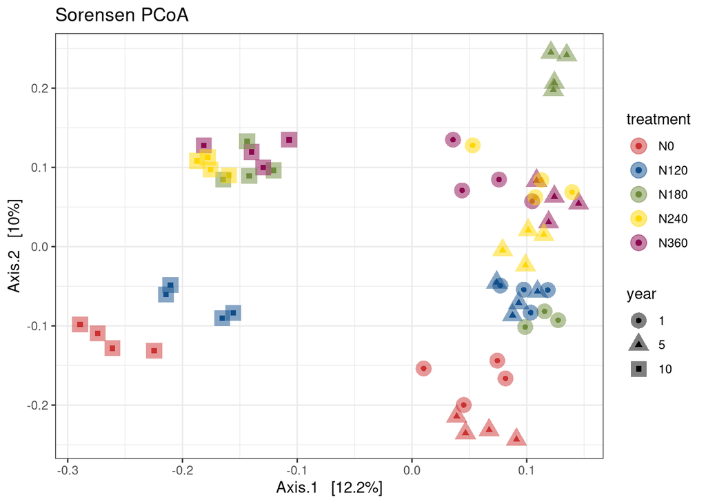

```r
# Calculate sorensen dissimilarity: Abundance-unweighted of shared taxa
scaled_soren_pcoa <-
  ordinate(
    physeq = scaled_rooted_physeq,
    method = "PCoA",
    distance = "bray", binary = TRUE)

#str(scaled_soren_pcoa)

# Plot the ordination
soren_treatment_pcoa <- plot_ordination(
  physeq = scaled_rooted_physeq,
  ordination = scaled_soren_pcoa,
  color = "treatment",
  shape = "year",
  title = "Sorensen PCoA") +
  geom_point(size=5, alpha = 0.5, aes(color = treatment)) +
  scale_color_manual(values = treatment_colors) +
  theme_bw()
# Show the plot
soren_treatment_pcoa
```

Here, I am evaluating the shared taxa by presence/absence (abundance-unweighted) in the Sorensen metric.

- Axis 1 = ~12.2% of variation
- Axis 2 = ~10% of variation

Axis 2 showed three distinct clusters from 1.N0 2.N120 3.N180, N240 and N360

### Bray

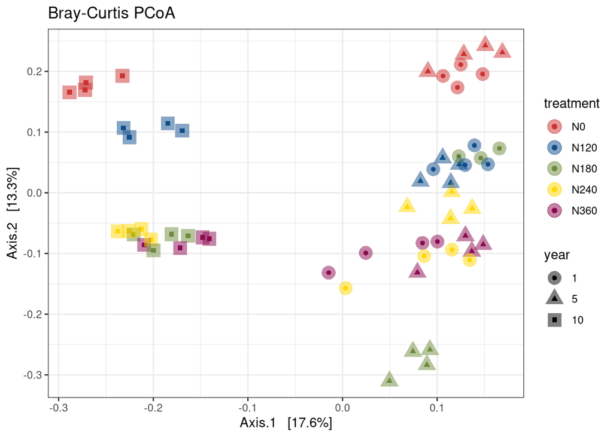

```r
# Calculate the BC distance
scaled_BC_pcoa <-
  ordinate(
    physeq = scaled_rooted_physeq,
    method = "PCoA",
    distance = "bray")

# Plot the PCoA
bray_treatment_pcoa <-
  plot_ordination(
    physeq = scaled_rooted_physeq,
    ordination = scaled_BC_pcoa,
    color = "treatment",
    shape = "year",
    title = "Bray-Curtis PCoA") +
  geom_point(size=5, alpha = 0.5, aes(color = treatment)) +
  scale_color_manual(values = c(treatment_colors)) +
  theme_bw()
bray_treatment_pcoa
```

From the Bray-curtis analysis:

This means that this analysis explains 31% of the variation in the data in these two axes, which is more than the previous plot with the Sorensen Dissimilarity. Abundance does seem to have an influence!!

Samples are now separated opposite to how they were separated in Sorenson.

### Weighted Unifrac

```r
# Calculate the BC distance
scaled_wUNI_pcoa <-
  ordinate(physeq = scaled_rooted_physeq,
    method = "PCoA",
    distance = "wunifrac")

str(scaled_wUNI_pcoa)
```

```
## List of 5
##  $ correction: chr [1:2] "none" "1"
##  $ note      : chr "No correction was applied to the negative eigenvalues"
##  $ values    :'data.frame':  59 obs. of  6 variables:
##   ..$ Eigenvalues   : num [1:59] 0.5712 0.4572 0.205 0.0879 0.0585 ...
##   ..$ Relative_eig  : num [1:59] 0.3382 0.2707 0.1214 0.052 0.0346 ...
##   ..$ Rel_corr_eig  : num [1:59] 0.203 0.164 0.0775 0.0374 0.0273 ...
##   ..$ Broken_stick  : num [1:59] 0.0812 0.0637 0.0549 0.049 0.0447 ...
##   ..$ Cum_corr_eig  : num [1:59] 0.203 0.367 0.444 0.482 0.509 ...
##   ..$ Cumul_br_stick: num [1:59] 0.0812 0.1449 0.1998 0.2488 0.2935 ...
##  $ vectors   : num [1:59, 1:45] -0.084 -0.1302 -0.1525 -0.165 0.0753 ...
##   ..- attr(*, "dimnames")=List of 2
##   .. ..$ : chr [1:59] "SRR11364336" "SRR11364337" "SRR11364338" "SRR11364339" ...
##   .. ..$ : chr [1:45] "Axis.1" "Axis.2" "Axis.3" "Axis.4" ...
##  $ trace     : num 1.69
##  - attr(*, "class")= chr "pcoa"
```

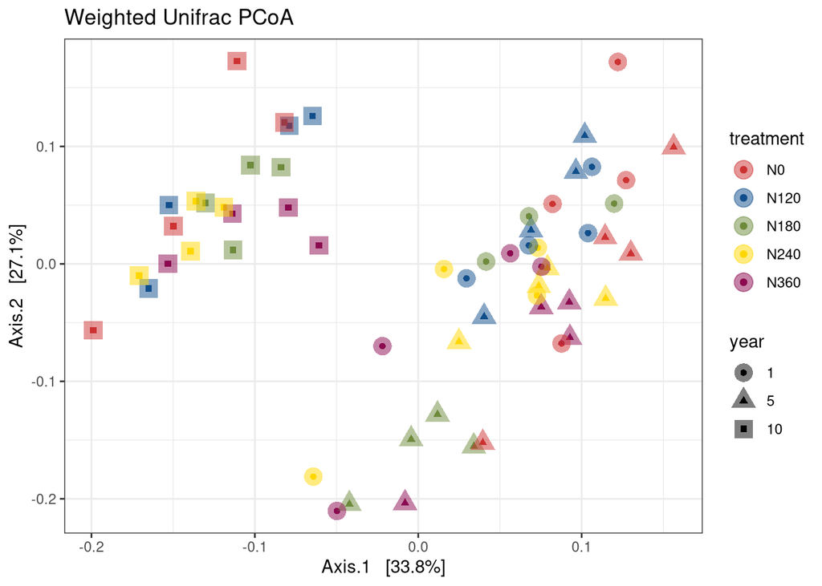

```r
# Plot the PCoA
wUNI_treatment_pcoa <-
  plot_ordination(
    physeq = scaled_rooted_physeq,
    ordination = scaled_wUNI_pcoa,
    color = "treatment",
    shape = "year",
    title = "Weighted Unifrac PCoA") +
  geom_point(size=5, alpha = 0.5, aes(color = treatment)) +
  scale_color_manual(values = c(treatment_colors)) +
  theme_bw()
wUNI_treatment_pcoa
```

Here, I am evaluating the shared taxa and then weighting them by their abundances, which provides more influence for species that are more abundant.

- Axis 1 = ~34% of variation
- Axis 2 = ~27% of variation

This means we explain *61*% of the variation in the data in these two axes, which is significantly more than the previous plots with the taxonomic dissimilarity measures. This plots shows two distinct clusters in both the axes, axis 2 showing all the samples form 10th year and axis 1 showing all the samples from all treatments in 1st and 5th year.

## Combine PCoAs

Let’s plot all three together into one plot to have a concise visualization of the three metrics.

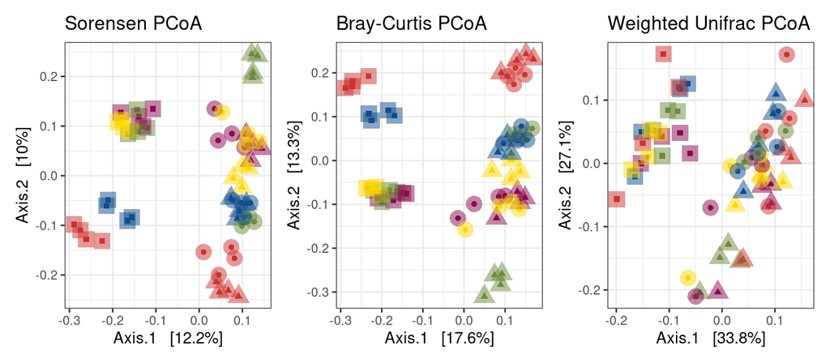

```r
(soren_treatment_pcoa + theme(legend.position = "none")) +
  (bray_treatment_pcoa + theme(legend.position = "none")) +
    (wUNI_treatment_pcoa + theme(legend.position = "none"))
```

## NMDS

### Weighted Unifrac

Since we did 3 of the dissimilarity metrics for the PCoA, let’s just plot one example of them for the NMDS plotting. Here, we will use weighted Unifrac

```r
# Calculate the Weighted Unifrac distance
scaled_wUNI_nmds <-
  ordinate(
    physeq = scaled_rooted_physeq,
    method = "NMDS",
    distance = "wunifrac")
```

```
## *** Best solution repeated 13 times
```

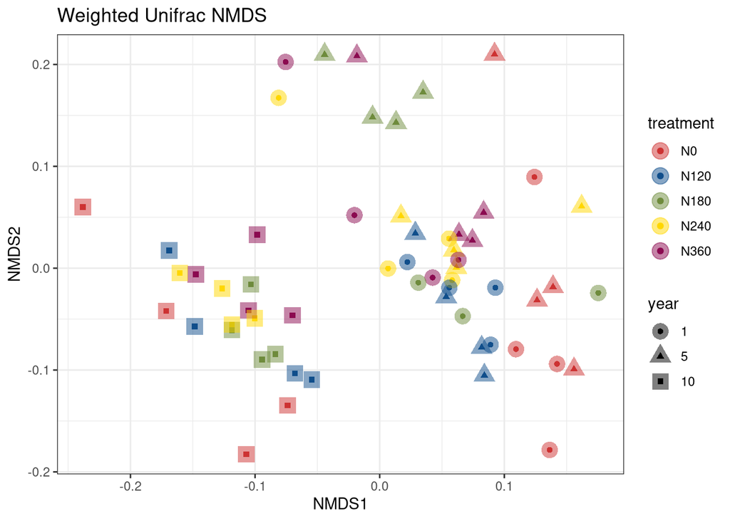

```r
# Plot the PCoA
wUNI_treatment_nmds <-
  plot_ordination(
    physeq = scaled_rooted_physeq,
    ordination = scaled_wUNI_nmds,
    color = "treatment",
    shape = "year",
    title = "Weighted Unifrac NMDS") +
  geom_point(size=5, alpha = 0.5, aes(color = treatment)) +
  scale_color_manual(values = c(treatment_colors)) +
  theme_bw()
wUNI_treatment_nmds
```

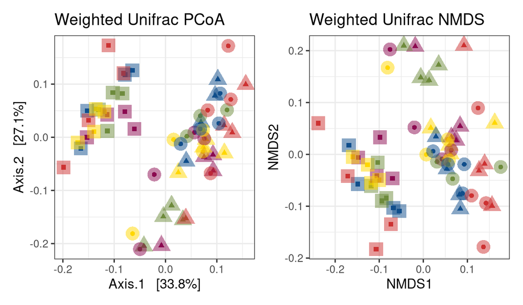

```r
(wUNI_treatment_pcoa + theme(legend.position = "none")) +
  (wUNI_treatment_nmds + theme(legend.position = "none"))
```

PCoA shows more variability as compared to NMDS.

# Statistical Significance Testing

## PERMANOVA

```r
# Calculate all three of the distance matrices
scaled_sorensen_dist <- phyloseq::distance(scaled_rooted_physeq, method = "bray", binary = TRUE)
scaled_bray_dist <- phyloseq::distance(scaled_rooted_physeq, method = "bray")
scaled_wUnifrac_dist <- phyloseq::distance(scaled_rooted_physeq, method = "wunifrac")

# make a data frame from the sample_data
# All distance matrices will be the same metadata because they
# originate from the same phyloseq object.
metadata <- data.frame(sample_data(scaled_rooted_physeq))

# Adonis test
# In this example we are testing the hypothesis that the five stations
# that were collected have different centroids in the ordination space
# for each of the dissimilarity metrics, we are using a discrete variable
adonis2(scaled_sorensen_dist ~ treatment, data = metadata)
```

```
## Permutation test for adonis under reduced model
## Terms added sequentially (first to last)
## Permutation: free
## Number of permutations: 999
##
## adonis2(formula = scaled_sorensen_dist ~ treatment, data = metadata)
##           Df SumOfSqs      R2      F Pr(>F)
## treatment  4   1.3170 0.14848 2.3539  0.001 ***
## Residual  54   7.5534 0.85152
## Total     58   8.8705 1.00000
## ---
## Signif. codes:  0 '***' 0.001 '**' 0.01 '*' 0.05 '.' 0.1 ' ' 1
```

```r
adonis2(scaled_bray_dist ~ treatment, data = metadata)
```

```
## Permutation test for adonis under reduced model
## Terms added sequentially (first to last)
## Permutation: free
## Number of permutations: 999
##
## adonis2(formula = scaled_bray_dist ~ treatment, data = metadata)
##           Df SumOfSqs      R2      F Pr(>F)
## treatment  4   1.4441 0.17852 2.9337  0.001 ***
## Residual  54   6.6451 0.82148
## Total     58   8.0891 1.00000
## ---
## Signif. codes:  0 '***' 0.001 '**' 0.01 '*' 0.05 '.' 0.1 ' ' 1
```

```r
adonis2(scaled_wUnifrac_dist ~ treatment, data = metadata)
```

```
## Permutation test for adonis under reduced model
## Terms added sequentially (first to last)
## Permutation: free
## Number of permutations: 999
##
## adonis2(formula = scaled_wUnifrac_dist ~ treatment, data = metadata)
##           Df SumOfSqs      R2      F Pr(>F)
## treatment  4  0.27532 0.16301 2.6293  0.001 ***
## Residual  54  1.41362 0.83699
## Total     58  1.68894 1.00000
## ---
## Signif. codes:  0 '***' 0.001 '**' 0.01 '*' 0.05 '.' 0.1 ' ' 1
```

We see that the most variation is explained by Bray-Curtis and Unifrac and also has the highest F-statistic.

```r
# We might also care about other variables
# Here, we will add year and treatment as variables
# multiplicative model ORDER MATTERS!
adonis2(scaled_sorensen_dist ~ treatment*year, data = metadata)
```

```
## Permutation test for adonis under reduced model
## Terms added sequentially (first to last)
## Permutation: free
## Number of permutations: 999
##
## adonis2(formula = scaled_sorensen_dist ~ treatment * year, data = metadata)
##                Df SumOfSqs      R2      F Pr(>F)
## treatment       4   1.3170 0.14848 3.1354  0.001 ***
## year            2   1.3492 0.15210 6.4238  0.001 ***
## treatment:year  8   1.5835 0.17852 1.8849  0.001 ***
## Residual       44   4.6207 0.52091
## Total          58   8.8705 1.00000
## ---
## Signif. codes:  0 '***' 0.001 '**' 0.01 '*' 0.05 '.' 0.1 ' ' 1
```

```r
adonis2(scaled_bray_dist ~ treatment*year, data = metadata)
```

```
## Permutation test for adonis under reduced model
## Terms added sequentially (first to last)
## Permutation: free
## Number of permutations: 999
##
## adonis2(formula = scaled_bray_dist ~ treatment * year, data = metadata)
##                Df SumOfSqs      R2       F Pr(>F)
## treatment       4   1.4441 0.17852  4.6332  0.001 ***
## year            2   1.6530 0.20435 10.6076  0.001 ***
## treatment:year  8   1.5636 0.19330  2.5085  0.001 ***
## Residual       44   3.4284 0.42383
## Total          58   8.0891 1.00000
## ---
## Signif. codes:  0 '***' 0.001 '**' 0.01 '*' 0.05 '.' 0.1 ' ' 1
```

```r
# Note that the ORDER MATTERS!
adonis2(scaled_wUnifrac_dist ~ treatment*year, data = metadata)
```

```
## Permutation test for adonis under reduced model
## Terms added sequentially (first to last)
## Permutation: free
## Number of permutations: 999
##
## adonis2(formula = scaled_wUnifrac_dist ~ treatment * year, data = metadata)
##                Df SumOfSqs      R2       F Pr(>F)
## treatment       4  0.27532 0.16301  5.4118  0.001 ***
## year            2  0.55729 0.32997 21.9089  0.001 ***
## treatment:year  8  0.29671 0.17568  2.9162  0.001 ***
## Residual       44  0.55961 0.33134
## Total          58  1.68894 1.00000
## ---
## Signif. codes:  0 '***' 0.001 '**' 0.01 '*' 0.05 '.' 0.1 ' ' 1
```

```r
adonis2(scaled_wUnifrac_dist ~ year*treatment, data = metadata)
```

```
## Permutation test for adonis under reduced model
## Terms added sequentially (first to last)
## Permutation: free
## Number of permutations: 999
##
## adonis2(formula = scaled_wUnifrac_dist ~ year * treatment, data = metadata)
##                Df SumOfSqs      R2       F Pr(>F)
## year            2  0.56020 0.33169 22.0231  0.001 ***
## treatment       4  0.27242 0.16129  5.3548  0.001 ***
## year:treatment  8  0.29671 0.17568  2.9162  0.001 ***
## Residual       44  0.55961 0.33134
## Total          58  1.68894 1.00000
## ---
## Signif. codes:  0 '***' 0.001 '**' 0.01 '*' 0.05 '.' 0.1 ' ' 1
```

From here, we see that the highest F-statistic is observed in Unifrac and year of sample selections impacts our results. The interaction between treatment type and the year of sampling also impacts are results from microbial community analysis, which are shown further.

## BetaDispR

The PERMANOVA is sensitive to variance/dispersion in the data. Therefore, we need to run a homogeneity of dispersion test to test for the sensitivity of our PERMANOVA results to variance.

```r
# Homogeneity of Disperson test with beta dispr
# Sorensen
beta_soren_treatment <- betadisper(scaled_sorensen_dist, metadata$treatment)
permutest(beta_soren_treatment)
```

```
##
## Permutation test for homogeneity of multivariate dispersions
## Permutation: free
## Number of permutations: 999
##
## Response: Distances
##           Df   Sum Sq    Mean Sq      F N.Perm Pr(>F)
## Groups     4 0.003877 0.00096916 1.4822    999  0.206
## Residuals 54 0.035309 0.00065387
```

```r
# Bray-curtis
beta_bray_treatment <- betadisper(scaled_bray_dist, metadata$treatment)
permutest(beta_bray_treatment)
```

```
##
## Permutation test for homogeneity of multivariate dispersions
## Permutation: free
## Number of permutations: 999
##
## Response: Distances
##           Df   Sum Sq   Mean Sq      F N.Perm Pr(>F)
## Groups     4 0.009616 0.0024040 1.6459    999  0.196
## Residuals 54 0.078871 0.0014606
```

```r
# Weighted Unifrac
beta_bray_treatment <- betadisper(scaled_wUnifrac_dist, metadata$treatment)
permutest(beta_bray_treatment)
```

```
##
## Permutation test for homogeneity of multivariate dispersions
## Permutation: free
## Number of permutations: 999
##
## Response: Distances
##           Df  Sum Sq   Mean Sq      F N.Perm Pr(>F)
## Groups     4 0.01343 0.0033575 1.4154    999  0.236
## Residuals 54 0.12809 0.0023721
```

# Taxonomic Composition

## Phylum

```r
# Set the phylum colors
phylum_colors <- c(
  Acidobacteriota = "navy",
  Actinobacteriota = "darkslategray2",
  Armatimonadota = "deeppink1",
  Alphaproteobacteria = "plum2",
  Bacteroidota = "gold",
  Bacteroidetes = "turquoise",
  Betaproteobacteria = "plum1",
  Bdellovibrionota = "red1",
  Chloroflexi="black",
  Gemmatimonadota = "firebrick",
  Cyanobacteria = "limegreen",
  Deltaproteobacteria = "grey",
  Desulfobacterota="magenta",
  Firmicutes = "#3E9B96",
  Gammaproteobacteria = "greenyellow",
  Gammatimonadetes = "khaki1",
  Myxococcota = "#B5D6AA",
  Nitrospirota = "palevioletred1",
  Nitrospirae = "lavender",
  Proteobacteria = "royalblue",
  Planctomycetota = "darkorange",
  Patescibacteria = "yellow",
  Thermoplasmatota = "green",
  Verrucomicrobiota = "darkorchid1",
  Latescibacterota = "pink1",
  Methylomirabilota = "springgreen2",
  Fibrobacterota = "olivedrab",
  other = "grey")
```

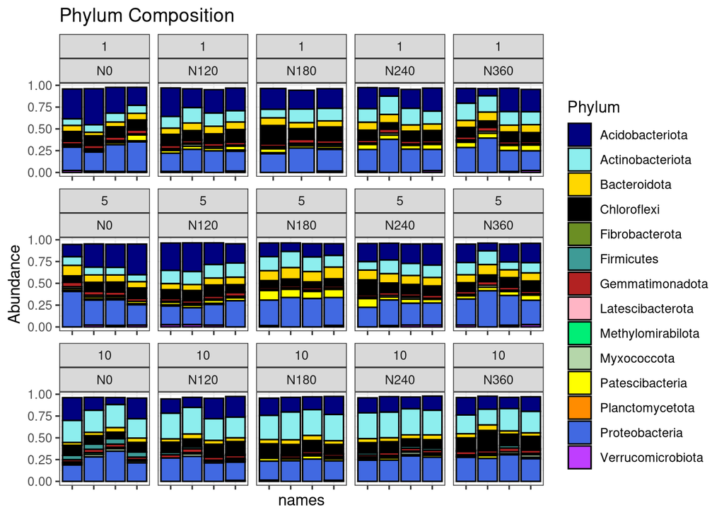

```r
# Calculate the phylum relative abundance
# Note: The read depth MUST be normalized in some way: scale_reads
phylum_df <-
  scaled_rooted_physeq %>%
  # agglomerate at the phylum level
  tax_glom(taxrank = "Phylum") %>%
  # Transform counts to relative abundance
  transform_sample_counts(function (x) {x/sum(x)}) %>%
  # Melt to a long format
  psmelt() %>%
  # Filter out Phyla that are <1% - get rid of low abundant Phyla
  dplyr::filter(Abundance > 0.01) %>%
  # fix the order of year
  mutate(year = fct_relevel(year, c("1", "5", "10")),
        treatment = fct_relevel(treatment, c("N0", "N120",
                                          "N180", "N240",
                                          "N360")))


# Stacked Bar Plot With All phyla
# Plot Phylum Abundances - make sure to load phylum_colors
phylum_df %>%
  ggplot(aes(x = names, y = Abundance, fill = Phylum)) +
  facet_wrap(year~treatment, scales = "free_x", ncol = 5) +
  geom_bar(stat = "identity", color = "black") +
  labs(title = "Phylum Composition") +
  scale_fill_manual(values = phylum_colors) +
  theme_bw() +
  theme(axis.text.x = element_blank())
```

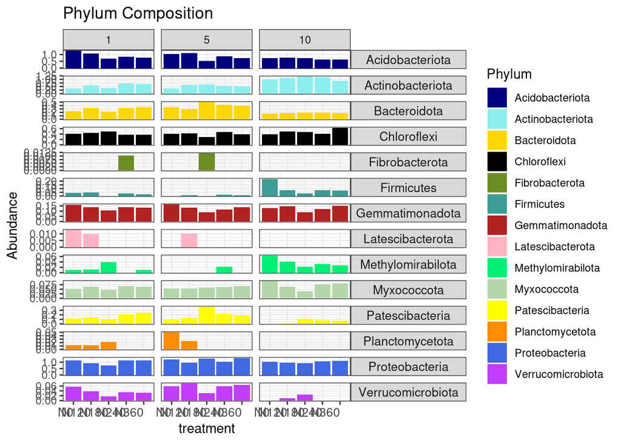

```r
## Make each phyla it's own row
phylum_df %>%
  # Warning: It's important to have one sample per x value,
  # otherwise, it will take the sum between multiple samples
  ggplot(aes(x = treatment, y = Abundance, fill = Phylum)) +
  facet_grid(Phylum~year, scale = "free") +
  geom_bar(stat = "identity") +
  labs(title = "Phylum Composition") +
  scale_fill_manual(values = phylum_colors) +
  theme_bw() +
  theme(axis.text.x = element_text( hjust = 1, vjust = 1, size = 10),
        strip.text.y = element_text(angle = 360,  size = 10 ))
```

[figure not shown]

```r
# Narrow in on a specific group
# Actinobacteriota - y: abundance, x: treatment, dot plot + boxplot
phylum_df %>%
  dplyr::filter(Phylum == "Actinobacteriota") %>%
  # build the plot
  ggplot(aes(x = treatment, y = Abundance,
             fill = treatment, color = treatment)) +
  geom_boxplot(alpha = 0.5, outlier.shape = NA) + # outliers not plotted here in boxplot
  facet_wrap(year~treatment, scales = "free_x", ncol = 5) +
  geom_jitter() +
  theme_bw() +
  labs(title = "Actinobacteriota Phylum Abundance") +
  scale_color_manual(values = treatment_colors) +
  scale_fill_manual(values = treatment_colors) +
    theme(axis.text.x = element_text(angle = 30, hjust = 1, vjust = 1),
          legend.position = "right")
```

[figure not shown]

```r
# Bacteroidota
phylum_df %>%
  dplyr::filter(Phylum == "Bacteroidota") %>%
  # build the plot
  ggplot(aes(x = treatment, y = Abundance,
             fill = treatment, color = treatment)) +
  geom_boxplot(alpha = 0.5, outlier.shape = NA) + # outliers not plotted here in boxplot
  facet_wrap(year~treatment, scales = "free_x", ncol = 5) +
  geom_jitter() +
  theme_bw() +
  labs(title = "Bacteroidota Phylum Abundance") +
  scale_color_manual(values = treatment_colors) +
  scale_fill_manual(values = treatment_colors) +
    theme(axis.text.x = element_text(angle = 30, hjust = 1, vjust = 1),
          legend.position = "right")
```

[figure not shown]

```r
# Acidobacteriota
phylum_df %>%
  dplyr::filter(Phylum == "Acidobacteriota") %>%
  # build the plot
  ggplot(aes(x = treatment, y = Abundance,
             fill = treatment, color = treatment)) +
  geom_boxplot(alpha = 0.5, outlier.shape = NA) + # outliers not plotted here in boxplot
  facet_wrap(year~treatment, scales = "free_x", ncol = 5) +
  geom_jitter() +
  theme_bw() +
  labs(title = "Acidobacteriota Phylum Abundance") +
  scale_color_manual(values = treatment_colors) +
  scale_fill_manual(values = treatment_colors) +
    theme(axis.text.x = element_text(angle = 30, hjust = 1, vjust = 1),
          legend.position = "right")
```

## Family

[figure not shown]

```r
# Calculate the Family relative abundance
# Note: The read depth MUST be normalized in some way: scale_reads

family_df <- scaled_rooted_physeq %>%
  # agglomerate at the phylum level
  tax_glom(taxrank = "Family") %>%
  # Transform counts to relative abundance
  transform_sample_counts(function (x) {x/sum(x)}) %>%
  # Melt to a long format
  psmelt() %>%
  # Filter out Phyla that are <1% - get rid of low abundant Phyla
  filter(Abundance > 0.01) %>%
  mutate(year = factor(year, levels = c("1", "5", "10")),
         treatment = factor(treatment, levels = c("N0", "N120", "N180", "N240", "N360")))

# Check family_df
#str(family_df)

# Plot family
# Actinobacteriota Families
family_df %>%
  dplyr::filter(Phylum == "Actinobacteriota") %>%
  # build the plot
  ggplot(aes(x = treatment, y = Abundance,
             fill = treatment, color = treatment)) +
  facet_wrap(year~treatment, scales = "free_x", ncol = 5) +
  geom_boxplot(alpha = 0.5, outlier.shape = NA) + # outliers not plotted here in boxplot
  geom_jitter() +
  theme_bw() +
  labs(title = "Actinobacteriota Family Abundance") +
  scale_color_manual(values = treatment_colors) +
  scale_fill_manual(values = treatment_colors) +
  theme(axis.text.x = element_text(angle = 30, hjust = 1, vjust = 1),
        legend.position = "bottom")
```

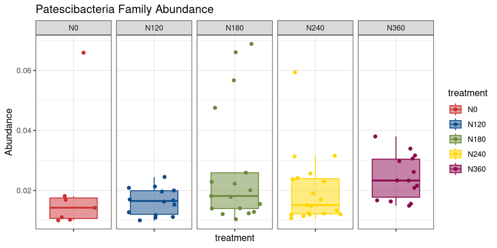

```r
# Plot family
family_df %>%
  dplyr::filter(Phylum == "Patescibacteria") %>%
  # build the plot
  ggplot(aes(x = treatment, y = Abundance,
             fill = treatment, color = treatment)) +
  facet_wrap(.~treatment, scales = "free_x", nrow = 1) +
  geom_boxplot(alpha = 0.5, outlier.shape = NA) + # outliers not plotted here in boxplot
  geom_jitter() +
  theme_bw() +
  labs(title = "Patescibacteria Family Abundance") +
  scale_color_manual(values = treatment_colors) +
  scale_fill_manual(values = treatment_colors) +
  theme(axis.text.x = element_blank())
```

## Genus

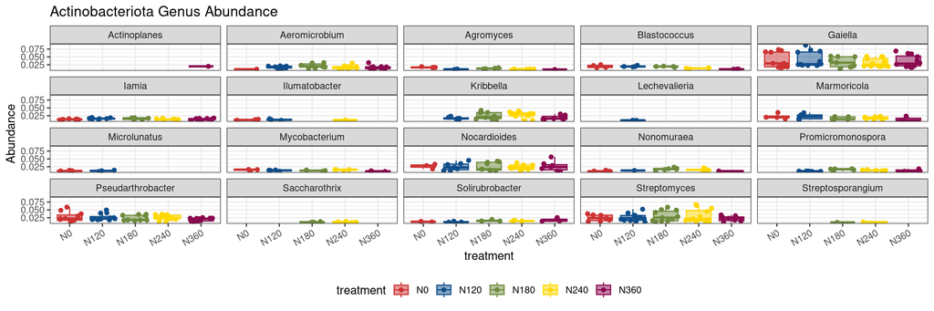

```r
# Calculate the Family relative abundance
# Note: The read depth MUST be normalized in some way: scale_reads
genus_df <-
  scaled_rooted_physeq %>%
  # agglomerate at the phylum level
  tax_glom(taxrank = "Genus") %>%
  # Transform counts to relative abundance
  transform_sample_counts(function (x) {x/sum(x)}) %>%
  # Melt to a long format
  psmelt() %>%
  # Filter out Phyla that are <1% - get rid of low abundant Phyla
  dplyr::filter(Abundance > 0.01) %>%
  # fix the order of year
  mutate(year = fct_relevel(year, c("1", "5", "10")),
         treatment = fct_relevel(treatment, c("N0", "N120",
                                          "N180", "N240",
                                          "N360")))


# Actinobacteriota
# Plot genus
genus_df %>%
  dplyr::filter(Phylum == "Actinobacteriota") %>%
  # build the plot
  ggplot(aes(x = treatment, y = Abundance,
             fill = treatment, color = treatment)) +
  facet_wrap(.~Genus) +
  geom_boxplot(alpha = 0.5, outlier.shape = NA) + # outliers not plotted here in boxplot
  geom_jitter() +
  theme_bw() +
  labs(title = "Actinobacteriota Genus Abundance") +
  scale_color_manual(values = treatment_colors) +
  scale_fill_manual(values = treatment_colors) +
  theme(axis.text.x = element_text(angle = 30, hjust = 1, vjust = 1),
        legend.position = "bottom")
```

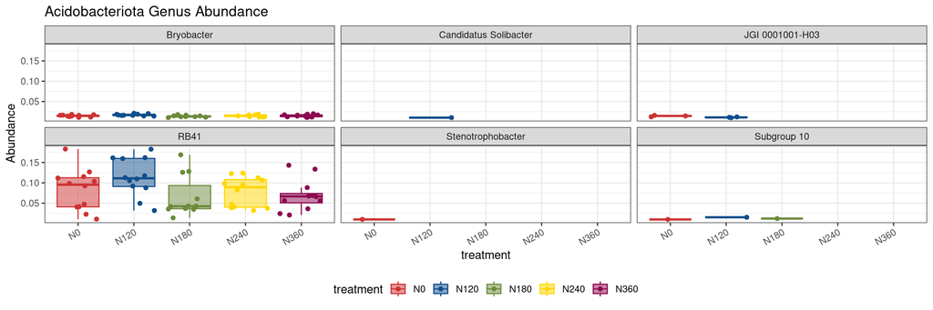

```r
# Acidobacteriota
# Plot genus
genus_df %>%
  dplyr::filter(Phylum == "Acidobacteriota") %>%
  # build the plot
  ggplot(aes(x = treatment, y = Abundance,
             fill = treatment, color = treatment)) +
  facet_wrap(.~Genus) +
  geom_boxplot(alpha = 0.5, outlier.shape = NA) + # outliers not plotted here in boxplot
  geom_jitter() +
  theme_bw() +
  labs(title = "Acidobacteriota Genus Abundance") +
  scale_color_manual(values = treatment_colors) +
  scale_fill_manual(values = treatment_colors) +
  theme(axis.text.x = element_text(angle = 30, hjust = 1, vjust = 1),
        legend.position = "bottom")
```